# Beginning Visualization and Data Exploration

kira

(Using [COVID-19 data](https://data.cityofnewyork.us/Health/COVID-19-Daily-Counts-of-Cases-Hospitalizations-an/rc75-m7u3) from NYC open data.)

# Starting out!

## Table

A table with daily averages is shown below:

| var | value |
| --- | --- |
| case | 435 |
| death | 7 |
| hospitalized | 31 |
| probable case | 86 |

Where can we go from here? what questions may be raised by this category?

## Additional Questions

(where can we go from there?)

- disaggregate by borough?
- patterns over time?

(what questions might we have?)

- what consitutes a “death”? Contributing factor? leading cause of death? etc.
- what is a “probable case”? How do they differ from just “cases”? How can we approximate likely actual cases – should we add them together?
- (this dataset is relatively well documented! So we can look at that documentation)
- But note: the documentation is outdated! we’ll have to poke around dataset to see how categories actually fit together.

# Disaggregate by boroughs

## An initial plot

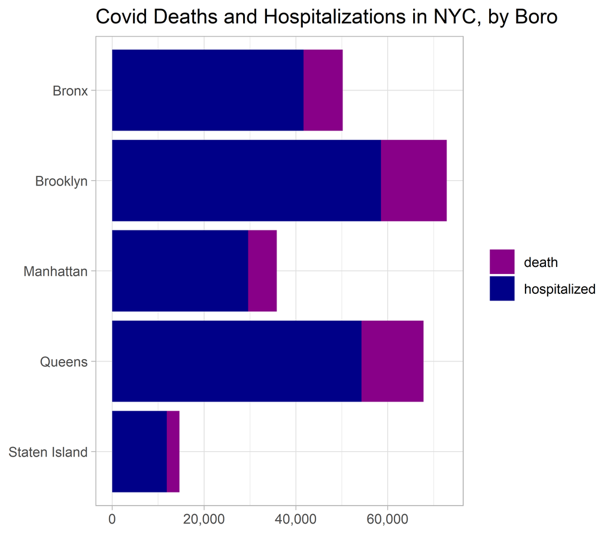

How could we go further again?

## Questions pt 2

- Adding caption for source!
- Adding takeaway title!
- normalizing by population. Ratio of hospitalization/deaths : population
- comparing ratios of hospitalization/deaths to cases, by borough (and over time?)
- Sorting boroughs more logically.. or mapping!

# Over time

```
## # A tibble: 9 × 2
##   var                              n
##   <chr>                        <int>
## 1 all case count 7day avg       6350
## 2 case count                    6350
## 3 case count 7day avg           6350
## 4 death count                   6350
## 5 death count 7day avg          6350
## 6 hospitalized count            6350
## 7 hospitalized count 7day avg   6350
## 8 probable case count           6350
## 9 probable case count 7day avg  6350
```

```
## # A tibble: 9 × 2
##   var                              n
##   <chr>                        <int>
## 1 all case count 7day avg       6350
## 2 case count                    6350
## 3 case count 7day avg           6350
## 4 death count                   6350
## 5 death count 7day avg          6350
## 6 hospitalized count            6350
## 7 hospitalized count 7day avg   6350
## 8 probable case count           6350
## 9 probable case count 7day avg  6350
```

```
## # A tibble: 5 × 2
##   var               n
##   <chr>         <int>
## 1 all case       6350
## 2 case           6350
## 3 death          6350
## 4 hospitalized   6350
## 5 probable case  6350
```

```
##    Min. 1st Qu.  Median    Mean 3rd Qu.    Max.
##    0.00    8.00   17.00   37.97   37.00  759.00
```

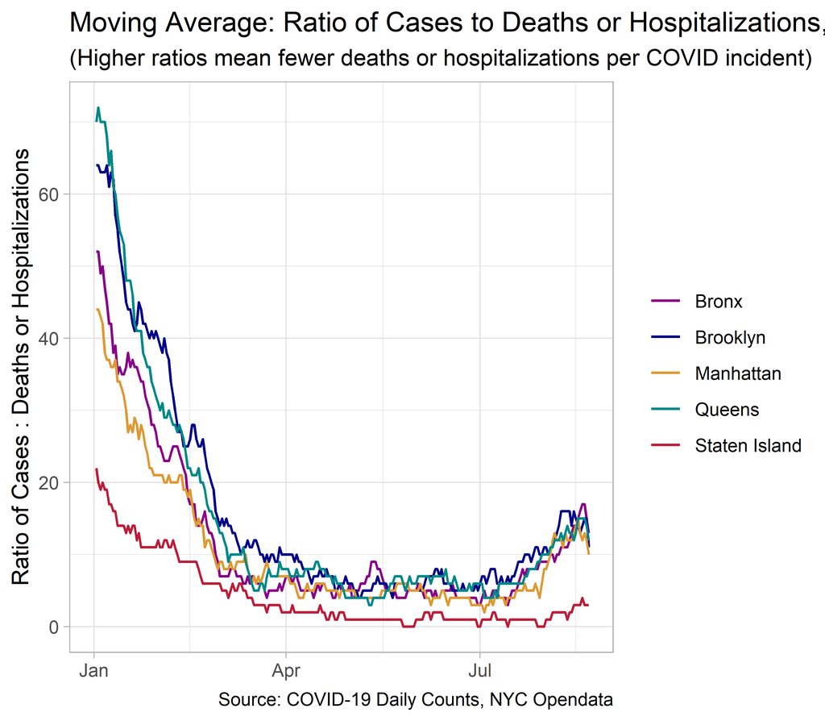

How could we interpret this graph? How can we frame or posit findings from it?

What additional questions might it raise? How could we begin to explore those?

# Add’l example NYC openData sets

- [Causes of deaths](https://data.cityofnewyork.us/Health/New-York-City-Leading-Causes-of-Death/jb7j-dtam)
- [Vehicle Crashes](https://data.cityofnewyork.us/Public-Safety/Motor-Vehicle-Collisions-Crashes/h9gi-nx95)
- [Covid Counts](https://data.cityofnewyork.us/Health/COVID-19-Daily-Counts-of-Cases-Hospitalizations-an/rc75-m7u3)
- Police reports